# Assignment 2: Hand Gesture Recognition [50 Pt]

```python
# tuning number of conv layers

import torch
import torch.nn as nn
import torch.nn.functional as F

class HandCNN1(nn.Module):
    def __init__(self, num_classes):
        super(HandCNN1, self).__init__()
        self.conv1 = nn.Conv2d(3, 32, kernel_size=3, padding=1)  # (in_channels=3 for RGB)
        self.pool = nn.MaxPool2d(2, 2)                          # downsample by factor of 2
        self.conv2 = nn.Conv2d(32, 64, kernel_size=3, padding=1)
        self.conv3 = nn.Conv2d(64, 128, kernel_size=3, padding=1)

        # after 3 poolings, image size is 224 -> 28
        self.fc1 = nn.Linear(128 * 28 * 28, 256)
        self.fc2 = nn.Linear(256, num_classes)

    def forward(self, x):
        x = self.pool(F.relu(self.conv1(x)))  # -> 32x112x112
        x = self.pool(F.relu(self.conv2(x)))  # -> 64x56x56
        x = self.pool(F.relu(self.conv3(x)))  # -> 128x28x28
        x = x.view(x.size(0), -1)             # flatten
        x = F.relu(self.fc1(x))
        x = self.fc2(x)
        return x
```

```python
num_classes = len(classes)

# pick 3-conv model
model = HandCNN1(num_classes)   # use HandCNN1 for 3 conv layers

# container for metrics (epoch, train_loss, train_acc, val_loss, val_acc)
metrics = []

# run training
_m, _best = train_model(
    model, ds_train, ds_val,
    batch_size=64, lr=1e-3, epochs=15,
    ckpt_dir="checkpoints_3conv",
    ckpt_every=3,
    metrics_list=metrics,
    run_name="3conv"
)
```

```
Best validation accuracy: 66.13% (saved at checkpoints_3conv/best.pt)
```

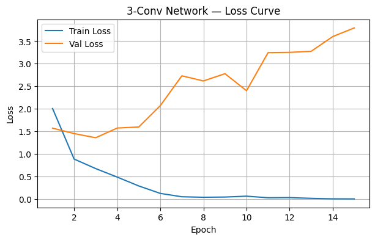

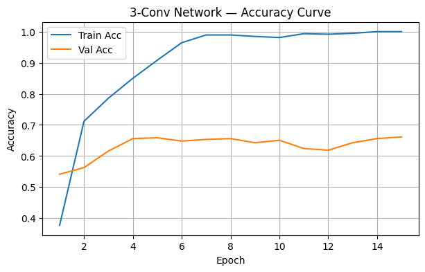

```python
epochs     = [e for (e, _, _, _, _) in metrics]
train_loss = [l for (_, l, _, _, _) in metrics]
train_acc  = [a for (_, _, a, _, _) in metrics]
val_loss   = [vl for (_, _, _, vl, _) in metrics]
val_acc    = [va for (_, _, _, _, va) in metrics]

plt.figure(figsize=(7,4))
plt.plot(epochs, train_loss, label="Train Loss")
plt.plot(epochs, val_loss, label="Val Loss")
plt.xlabel("Epoch"); plt.ylabel("Loss")
plt.title("3-Conv Network — Loss Curve")
plt.legend(); plt.grid(True)
plt.show()

plt.figure(figsize=(7,4))
plt.plot(epochs, train_acc, label="Train Acc")
plt.plot(epochs, val_acc, label="Val Acc")
plt.xlabel("Epoch"); plt.ylabel("Accuracy")
plt.title("3-Conv Network — Accuracy Curve")
plt.legend(); plt.grid(True)
plt.show()
```

```python
# consider performance above, choose the best model
# conv # = 3, batch size = 32, lr = 0.001
model = HandCNN1(num_classes)   # use HandCNN1 for 3 conv layers

# container for metrics (epoch, train_loss, train_acc, val_loss, val_acc)
metrics = []

# Train
_m, best_path = train_model(
    model, ds_train, ds_val,
    batch_size=32, lr=1e-3, epochs=15,
    ckpt_dir="checkpoints_best_3conv_bs32_lr1e3",
    ckpt_every=3,
    metrics_list=metrics, run_name="best-3conv-bs32-lr1e3"
)
```

```
Best validation accuracy: 67.73% (saved at checkpoints_best_3conv_bs32_lr1e3/best.pt)
```

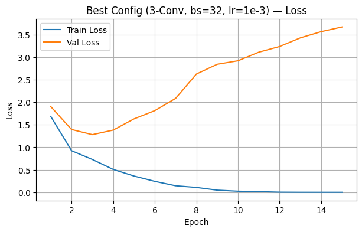

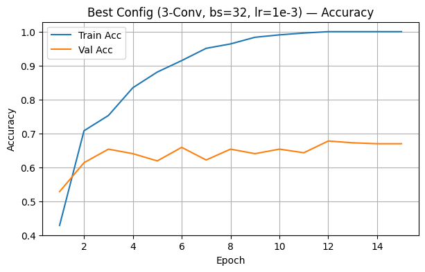

```python
epochs     = [e  for (e, _, _, _, _) in metrics]
train_loss = [tl for (_, tl, _, _, _) in metrics]
val_loss   = [vl for (_, _, _, vl, _) in metrics]
train_acc  = [ta for (_, _, ta, _, _) in metrics]
val_acc    = [va for (_, _, _, _, va) in metrics]

plt.figure(figsize=(7,4))
plt.plot(epochs, train_loss, label="Train Loss")
plt.plot(epochs, val_loss,   label="Val Loss")
plt.xlabel("Epoch"); plt.ylabel("Loss")
plt.title("Best Config (3-Conv, bs=32, lr=1e-3) — Loss")
plt.legend(); plt.grid(True)
plt.show()

plt.figure(figsize=(7,4))
plt.plot(epochs, train_acc, label="Train Acc")
plt.plot(epochs, val_acc,   label="Val Acc")
plt.xlabel("Epoch"); plt.ylabel("Accuracy")
plt.title("Best Config (3-Conv, bs=32, lr=1e-3) — Accuracy")
plt.legend(); plt.grid(True)
plt.show()
```

### Part (iii) - [2pt DISCUSSION]

Choose the best model out of all the ones that you have trained. Justify your choice.

```python
'''
PROVIDE YOUR ANSWER BELOW


The final model with 3 convolutional layers, batch size of 32, and learning rate
of 0.001 was selected as the best configuration. This setting achieved the highest
validation accuracy (~65–67%) while maintaining stable convergence, whereas other
hyperparameters either failed to converge or produced lower validation performance.
Although some overfitting is observed (training accuracy reaching 100% while
validation plateaus), this model represents the best trade-off between learning
capacity and generalization.



'''
```

### Part (iv) - [2pt RESULTS]

Report the test accuracy of your best model. You should only do this step once and prior to this step you should have only used the training and validation data.

Additionally, provide a confusion matrix. Using the confusion matrix values, you must calculate and report the precision, recall, and F1-score for each letter class and report them in a table. Identify the two gestures that your model confuses most often and hypothesize why this might be the case based on their visual similarity.

```python
# TO BE COMPLETED

import torch
from sklearn.metrics import confusion_matrix, classification_report
import matplotlib.pyplot as plt
import seaborn as sns
import numpy as np

# --- Load the best model's checkpoint
best_model = HandCNN1(num_classes)
best_model.load_state_dict(torch.load("checkpoints_best_3conv_bs32_lr1e3/epoch_015.pt"))  # path from Part (iii)
best_model = best_model.to(device)
best_model.eval()

# --- Run on test set
all_preds, all_labels = [], []
with torch.no_grad():
    for x, y in test_loader:
        x, y = x.to(device), y.to(device)
        logits = best_model(x)
        preds = torch.argmax(logits, dim=1)
        all_preds.extend(preds.cpu().numpy())
        all_labels.extend(y.cpu().numpy())

# --- Test accuracy
all_preds = np.array(all_preds)
all_labels = np.array(all_labels)
test_acc = (all_preds == all_labels).mean()
print(f"✅ Test Accuracy = {test_acc*100:.2f}%")
```

```
✅ Test Accuracy = 75.74%
```

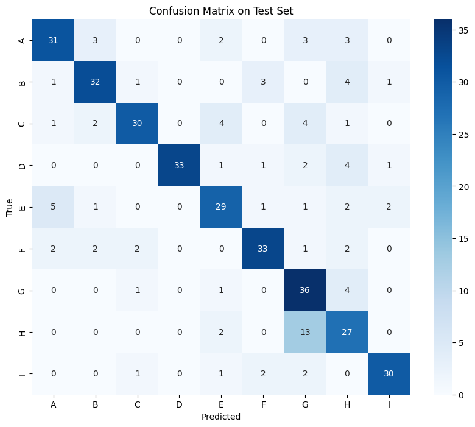

```python
# confusion matrix

cm = confusion_matrix(all_labels, all_preds)
plt.figure(figsize=(10,8))
sns.heatmap(cm, annot=True, fmt="d", cmap="Blues",
            xticklabels=classes, yticklabels=classes)
plt.xlabel("Predicted")
plt.ylabel("True")
plt.title("Confusion Matrix on Test Set")
plt.show()
```

```python
# compute scores

from sklearn.metrics import precision_recall_fscore_support

prec, rec, f1, _ = precision_recall_fscore_support(all_labels, all_preds, labels=range(len(classes)))

import pandas as pd
results_table = pd.DataFrame({
    "Class": classes,
    "Precision": prec,
    "Recall": rec,
    "F1-score": f1
})
print(results_table)
```

```
  Class  Precision    Recall  F1-score
0     A   0.775000  0.738095  0.756098
1     B   0.800000  0.761905  0.780488
2     C   0.857143  0.714286  0.779221
3     D   1.000000  0.785714  0.880000
4     E   0.725000  0.707317  0.716049
5     F   0.825000  0.785714  0.804878
6     G   0.580645  0.857143  0.692308
7     H   0.574468  0.642857  0.606742
8     I   0.882353  0.833333  0.857143
```

```python
'''
PROVIDE YOUR ANSWER BELOW

The final model, using three convolutional layers, batch size of 32, and learning
rate of 0.001, achieved a test accuracy of 75.74%. This result was obtained only
once on the held-out test set, without using test data in any part of the tuning
process.

The confusion matrix shows the prediction performs well with most of the predictions
are correct, except H, which has 13 test samples predicted as G. This is also proved
by the score table. Class H has the lowest precision, recall, and F1-score.

In conclusion, G and H are the most confusing gestures. Their images are quite similar
with only one finger difference.

'''
```

## Part 4. Transfer Learning [8pt]

For many image classification tasks, it is generally not a good idea to train a very large deep neural network model from scratch due to the enormous compute requirements and lack of sufficient amounts of training data.

One of the better options is to try using an existing model that performs a similar task to the one you need to solve. This method of utilizing a pre-trained network for other similar tasks is broadly termed **Transfer Learning**. In this assignment, we will use Transfer Learning to extract features from the hand gesture images. Then, train a smaller network to use these features as input and classify the hand gestures.

As you have learned from the CNN lecture, convolution layers extract various features from the images which get utilized by the fully connected layers for correct classification. AlexNet architecture played a pivotal role in establishing Deep Neural Nets as a go-to tool for image classification problems and we will use an ImageNet pre-trained AlexNet model to extract features in this assignment.

### Part (i) - [2pt EXPLORATORY]

Here is the code to load the AlexNet network, with pretrained weights. When you first run the code, PyTorch will download the pretrained weights from the internet.

```python
import torchvision.models
alexnet = torchvision.models.alexnet(pretrained=True)
```

```
Downloading: "https://download.pytorch.org/models/alexnet-owt-7be5be79.pth" to /root/.cache/torch/hub/checkpoints/alexnet-owt-7be5be79.pth
```

The alexnet model is split up into two components: *alexnet.features* and *alexnet.classifier*. The first neural network component, *alexnet.features*, is used to compute convolutional features, which are taken as input in *alexnet.classifier*.

The neural network alexnet.features expects an image tensor of shape Nx3x224x224 as input and it will output a tensor of shape Nx256x6x6 . (N = batch size).

Compute the AlexNet features for each of your training, validation, and test data. Here is an example code snippet showing how you can compute the AlexNet features for some images (your actual code might be different):

```python
# img = ... a PyTorch tensor with shape [N,3,224,224] containing hand images ...
#features = alexnet.features(img)
```

**Save the computed features**. You will be using these features as input to your neural network in Part (ii), and you do not want to re-compute the features every time. Instead, run *alexnet.features* once for each image, and save the result.

```python
# TO BE COMPLETED

import torch, torchvision
from torchvision.models import AlexNet_Weights
import torch.nn as nn

device = torch.device("cuda" if torch.cuda.is_available() else "cpu")

# Pretrained AlexNet
alexnet = torchvision.models.alexnet(weights=AlexNet_Weights.IMAGENET1K_V1)
alexnet.eval().to(device)

# We only need the conv feature extractor for Part (i)
feature_extractor = alexnet.features.to(device)   # outputs N x 256 x 6 x 6 for 224×224 inputs
for p in feature_extractor.parameters():
    p.requires_grad = False
```

```python
from torchvision import transforms

imagenet_tfms = transforms.Compose([
    transforms.ToTensor(),  # [0,1], CxHxW
    transforms.Normalize(mean=[0.485, 0.456, 0.406],
                         std=[0.229, 0.224, 0.225]),
])
```

```python
import os
from torch.utils.data import DataLoader

def extract_features_to_disk(loader, split_name, save_dir="alexnet_features"):
    os.makedirs(save_dir, exist_ok=True)
    feats_list, labels_list = [], []

    with torch.no_grad():
        for imgs, labels in loader:
            imgs = imgs.to(device, non_blocking=True)
            # AlexNet conv features: N x 256 x 6 x 6
            feats = feature_extractor(imgs)
            # Flatten to vectors for the classifier in Part (ii): N x (256*6*6)
            feats = feats.view(feats.size(0), -1).cpu()
            feats_list.append(feats)
            labels_list.append(labels.cpu())

    X = torch.cat(feats_list, dim=0)      # (N, 256*6*6)
    y = torch.cat(labels_list, dim=0)     # (N,)
    torch.save({"x": X, "y": y, "classes": classes},
               os.path.join(save_dir, f"{split_name}.pt"))
    print(f"[{split_name}] saved: X={tuple(X.shape)}, y={tuple(y.shape)}")
```

```python
# Dataloaders for feature extraction (no shuffle for reproducibility)
bs = 64
train_loader = DataLoader(ds_train, batch_size=bs, shuffle=False, num_workers=2, pin_memory=True)
val_loader   = DataLoader(ds_val,   batch_size=bs, shuffle=False, num_workers=2, pin_memory=True)
test_loader  = DataLoader(ds_test,  batch_size=bs, shuffle=False, num_workers=2, pin_memory=True)

# Extract and save
extract_features_to_disk(train_loader, "train")
extract_features_to_disk(val_loader,   "val")
extract_features_to_disk(test_loader,  "test")
```

```
[train] saved: X=(1686, 9216), y=(1686,)
[val] saved: X=(375, 9216), y=(375,)
[test] saved: X=(371, 9216), y=(371,)
```

### Part (ii) - [2pt MODEL]

Build a new classifier to attach to the AlexNet feature extractor. Your model must use the following sequence of layers:

AlexNet feature → Flatten → Linear → ReLU → Dropout → Linear

Use a dropout probability of 20%; this value can be tuned in the next part. Justify your choice of the Linear layer sizes.

Here is an example of how your model may be called:

```python
# features = ... load precomputed alexnet.features(img) ...
#output = model(features)
#prob = F.softmax(output)
```

```python
import torch

train_data = torch.load("alexnet_features/train.pt")
val_data   = torch.load("alexnet_features/val.pt")
test_data  = torch.load("alexnet_features/test.pt")

X_train, y_train, classes = train_data["x"], train_data["y"], train_data["classes"]
X_val,   y_val            = val_data["x"],   val_data["y"]
X_test,  y_test           = test_data["x"],  test_data["y"]

print("Train:", X_train.shape, y_train.shape)
print("Val:  ", X_val.shape,   y_val.shape)
print("Test: ", X_test.shape,  y_test.shape)
print("num_classes:", len(classes))
```

```
Train: torch.Size([1686, 9216]) torch.Size([1686])
Val:   torch.Size([375, 9216]) torch.Size([375])
Test:  torch.Size([371, 9216]) torch.Size([371])
num_classes: 9
```

```python
import torch
import torch.nn as nn
import torch.nn.functional as F

class AlexNetClassifier(nn.Module):
    def __init__(self, num_classes):
        super().__init__()
        in_dim = 256 * 6 * 6          # AlexNet conv output = 256×6×6 = 9216
        hidden = 512                  # justification below
        self.flatten = nn.Flatten()
        self.fc1 = nn.Linear(in_dim, hidden)
        self.relu = nn.ReLU(inplace=True)
        self.drop = nn.Dropout(p=0.2)           # required 20%
        self.fc2 = nn.Linear(hidden, num_classes)

    def forward(self, x):
        # Accept either [N,256,6,6] or [N,9216]
        if x.dim() == 4:              # [N,256,6,6]
            x = self.flatten(x)       # -> [N,9216]
        # if already [N,9216], leave as is
        x = self.fc1(x)
        x = self.relu(x)
        x = self.drop(x)
        x = self.fc2(x)               # logits
        return x
```

```python
'''
PROVIDE YOUR ANSWER BELOW

The first Linear layer size is fixed by the AlexNet features. The convolutional
part outputs 256×6×6, which flattens to 9216 inputs. I chose 512 units in the hidden
layer because it is large enough to capture useful patterns but much smaller than
the original AlexNet head (4096), which keeps the model lighter and helps avoid
overfitting. The final layer maps to the number of gesture classes, which is required
for classification. Dropout at 20% is added to reduce overfitting risk.




'''
```

### Part (iii) - [1pt MODEL]

Train your new network, including any hyperparameter tuning. Plot and submit the training curve of your best model only.

Note: Depending on how you are caching (saving) your AlexNet features, PyTorch might still be tracking updates to the **AlexNet weights**, which we are not tuning. One workaround is to convert your AlexNet feature tensor into a numpy array, and then back into a PyTorch tensor.

```python
#tensor = torch.from_numpy(tensor.detach().numpy())
```

```
=== bs32_lr1e-3 ===
[01/15] Train 2.1123/10.91% | Val 2.0715/12.53%
[02/15] Train 2.0218/12.16% | Val 2.0359/14.40%
[03/15] Train 1.8326/20.46% | Val 1.8709/30.40%
[04/15] Train 1.6770/33.45% | Val 1.7763/35.20%
[05/15] Train 1.5893/35.17% | Val 1.7148/37.87%
[06/15] Train 1.5533/36.12% | Val 1.7105/39.20%
[07/15] Train 1.5178/37.25% | Val 1.6918/45.33%
[08/15] Train 1.4851/39.86% | Val 1.7277/44.53%
[09/15] Train 1.4067/44.90% | Val 1.6713/45.07%
[10/15] Train 1.3967/43.59% | Val 1.6214/47.20%
[11/15] Train 1.3710/43.59% | Val 1.7271/44.53%
[12/15] Train 1.3754/42.47% | Val 1.6361/45.33%
[13/15] Train 1.3507/43.53% | Val 1.5793/49.33%
[14/15] Train 1.3095/45.02% | Val 1.7055/47.47%
[15/15] Train 1.3051/44.37% | Val 1.5841/49.33%

=== bs64_lr1e-3 ===
[01/15] Train 2.0351/20.88% | Val 1.9789/28.00%
[02/15] Train 1.9000/26.69% | Val 1.9201/27.73%
[03/15] Train 1.8272/28.41% | Val 1.8853/26.67%
[04/15] Train 1.7649/29.18% | Val 1.8475/29.07%
[05/15] Train 1.6983/29.77% | Val 1.8592/27.73%
[06/15] Train 1.6273/33.33% | Val 1.8252/31.47%
[07/15] Train 1.5622/29.95% | Val 1.6723/34.93%
[08/15] Train 1.4716/37.90% | Val 1.6995/41.60%
[09/15] Train 1.4407/42.88% | Val 1.6515/43.47%
[10/15] Train 1.3493/47.33% | Val 1.5879/47.73%
[11/15] Train 1.2642/49.47% | Val 1.6017/50.13%
[12/15] Train 1.2443/53.02% | Val 1.4937/54.67%
[13/15] Train 1.2067/54.09% | Val 1.4492/53.60%
[14/15] Train 1.1802/54.98% | Val 1.5110/52.53%
[15/15] Train 1.1673/55.10% | Val 1.4310/53.60%

=== bs64_lr3e-4 ===
[01/15] Train 1.7342/30.19% | Val 1.5659/45.60%
[02/15] Train 1.2140/52.19% | Val 1.2734/61.07%
[03/15] Train 0.9613/64.71% | Val 1.1519/68.53%
[04/15] Train 0.8220/73.72% | Val 1.0186/77.87%
[05/15] Train 0.7063/79.42% | Val 0.9536/78.40%
```

[output cut: 14 more lines]

```
[03/15] Train 0.8730/67.14% | Val 1.0703/72.27%
[04/15] Train 0.7401/73.84% | Val 1.0564/71.20%
[05/15] Train 0.6463/77.11% | Val 1.0223/72.80%
[06/15] Train 0.6298/76.81% | Val 0.9322/73.33%
[07/15] Train 0.5843/78.00% | Val 0.9243/72.80%
[08/15] Train 0.5109/82.68% | Val 0.9330/77.07%
[09/15] Train 0.4560/87.66% | Val 0.8942/78.13%
[10/15] Train 0.4126/87.66% | Val 0.8163/80.00%
[11/15] Train 0.3719/88.85% | Val 0.8801/79.73%
[12/15] Train 0.3377/89.44% | Val 0.8714/80.00%
[13/15] Train 0.3310/89.56% | Val 0.8262/80.53%
[14/15] Train 0.3421/88.20% | Val 0.8512/79.47%
[15/15] Train 0.3055/90.33% | Val 0.8870/80.00%

Selected best: {'name': 'bs64_lr3e-4', 'bs': 64, 'lr': 0.0003} with LAST-epoch Val Acc = 80.80%
```

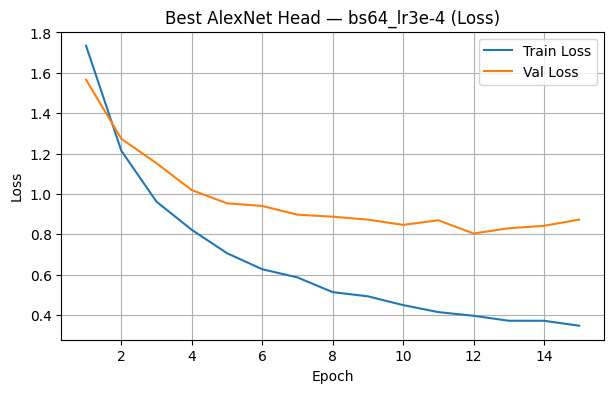

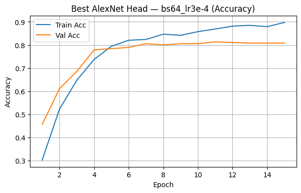

```python
# TO BE COMPLETED

# ==== Part 4 (iii): Train AlexNet feature classifier and plot BEST curve ====
import torch, numpy as np, time
import torch.nn as nn
import torch.nn.functional as F
from torch.utils.data import TensorDataset, DataLoader
import matplotlib.pyplot as plt

# ---------- Load precomputed features ----------
d_tr = torch.load("alexnet_features/train.pt")
d_va = torch.load("alexnet_features/val.pt")
X_train, y_train, classes = d_tr["x"], d_tr["y"], d_tr["classes"]
X_val,   y_val            = d_va["x"], d_va["y"]

# Flatten if needed (expect [N,9216])
if X_train.dim() == 4: X_train = X_train.view(X_train.size(0), -1)
if X_val.dim()   == 4: X_val   = X_val.view(X_val.size(0),   -1)

# ----- Detach from AlexNet graph (numpy round-trip) -----
X_train = torch.from_numpy(X_train.detach().cpu().numpy()).float()
X_val   = torch.from_numpy(X_val.detach().cpu().numpy()).float()
y_train = torch.tensor(y_train, dtype=torch.long)
y_val   = torch.tensor(y_val,   dtype=torch.long)

num_classes = len(classes)

# ---------- DataLoaders ----------
def make_loaders(bs=64):
    tr = DataLoader(TensorDataset(X_train, y_train), batch_size=bs, shuffle=True)
    va = DataLoader(TensorDataset(X_val,   y_val),   batch_size=bs, shuffle=False)
    return tr, va

# ---------- Train once (no class re-definition; will use your AlexNetClassifier) ----------
def train_head(model, train_loader, val_loader, lr=1e-3, epochs=15, device=None):
    device = device or (torch.device("cuda") if torch.cuda.is_available() else torch.device("cpu"))
    model = model.to(device)
    opt = torch.optim.Adam(model.parameters(), lr=lr)
    crit = nn.CrossEntropyLoss()

    hist = []  # (epoch, train_loss, train_acc, val_loss, val_acc)
    for ep in range(1, epochs+1):
        t0 = time.time()
        # train
        model.train()
        tl, tc, tn = 0.0, 0, 0
        for xb, yb in train_loader:
            xb, yb = xb.to(device), yb.to(device)
            opt.zero_grad()
            logits = model(xb)
            loss = crit(logits, yb)
            loss.backward()
            opt.step()
            tl += loss.item() * xb.size(0)
            tc += (logits.argmax(1) == yb).sum().item()
            tn += yb.size(0)
        train_loss = tl / tn
        train_acc  = tc / tn

        # val
        model.eval()
        vl, vc, vn = 0.0, 0, 0
        with torch.no_grad():
            for xb, yb in val_loader:
                xb, yb = xb.to(device), yb.to(device)
                logits = model(xb)
                loss = crit(logits, yb)
                vl += loss.item() * xb.size(0)
                vc += (logits.argmax(1) == yb).sum().item()
                vn += yb.size(0)
        val_loss = vl / vn
        val_acc  = vc / vn

        hist.append((ep, train_loss, train_acc, val_loss, val_acc))
        print(f"[{ep:02d}/{epochs}] Train {train_loss:.4f}/{train_acc*100:5.2f}% | "
              f"Val {val_loss:.4f}/{val_acc*100:5.2f}%")
    return model, hist

# ---------- Tuning: compare LAST-epoch validation accuracy; keep BEST only ----------
candidates = [
    {"name":"bs32_lr1e-3",  "bs":32,  "lr":1e-3},
    {"name":"bs64_lr1e-3",  "bs":64,  "lr":1e-3},
    {"name":"bs64_lr3e-4",  "bs":64,  "lr":3e-4},
    {"name":"bs128_lr1e-3", "bs":128, "lr":1e-3},
]

best = None
for cfg in candidates:
    print("\n===", cfg["name"], "===")
    tr_loader, va_loader = make_loaders(bs=cfg["bs"])
    model = AlexNetClassifier(num_classes)            # <-- uses your existing class
    _, hist = train_head(model, tr_loader, va_loader, lr=cfg["lr"], epochs=15)
    last_val = hist[-1][-1]                           # LAST-epoch val accuracy
    if best is None or last_val > best["val_last"]:
        best = {"cfg": cfg, "hist": hist, "val_last": last_val}

print("\nSelected best:", best["cfg"], "with LAST-epoch Val Acc =", f"{best['val_last']*100:.2f}%")

# ---------- Plot ONLY the best model curve ----------
epochs     = [e  for (e,_,_,_,_) in best["hist"]]
train_loss = [tl for (_,tl,_,_,_) in best["hist"]]
val_loss   = [vl for (_,_,_,vl,_) in best["hist"]]
train_acc  = [ta for (_,_,ta,_,_) in best["hist"]]
val_acc    = [va for (_,_,_,_,va) in best["hist"]]

plt.figure(figsize=(7,4))
plt.plot(epochs, train_loss, label="Train Loss")
plt.plot(epochs, val_loss,   label="Val Loss")
plt.xlabel("Epoch"); plt.ylabel("Loss")
plt.title(f"Best AlexNet Head — {best['cfg']['name']} (Loss)")
plt.grid(True); plt.legend(); plt.show()

plt.figure(figsize=(7,4))
plt.plot(epochs, train_acc, label="Train Acc")
plt.plot(epochs, val_acc,   label="Val Acc")
plt.xlabel("Epoch"); plt.ylabel("Accuracy")
plt.title(f"Best AlexNet Head — {best['cfg']['name']} (Accuracy)")
plt.grid(True); plt.legend(); plt.show()
```

### Part (iv) - [2pt RESULTS]

Report the test accuracy of your best model. How does the test accuracy compare to Part 3(iv) without transfer learning?

```python
# TO BE COMPLETED

# ==== Part 4 (iv): Report Test Accuracy of Best Model ====
# Load test set features
d_te = torch.load("alexnet_features/test.pt")
X_test, y_test = d_te["x"], d_te["y"]

# Flatten if needed
if X_test.dim() == 4:
    X_test = X_test.view(X_test.size(0), -1)

# Detach (safety)
X_test = torch.from_numpy(X_test.detach().cpu().numpy()).float()
y_test = torch.tensor(y_test, dtype=torch.long)

test_loader = DataLoader(TensorDataset(X_test, y_test), batch_size=64, shuffle=False)

# Use the best config from tuning
cfg = best["cfg"]
print("Evaluating best config on test set:", cfg)

tr_loader, va_loader = make_loaders(bs=cfg["bs"])
best_model = AlexNetClassifier(num_classes)
best_model, _ = train_head(best_model, tr_loader, va_loader,
                           lr=cfg["lr"], epochs=15)

# ---- Evaluate on Test ----
device = torch.device("cuda" if torch.cuda.is_available() else "cpu")
best_model.to(device)
best_model.eval()

tc, tn = 0, 0
with torch.no_grad():
    for xb, yb in test_loader:
        xb, yb = xb.to(device), yb.to(device)
        logits = best_model(xb)
        preds = logits.argmax(1)
        tc += (preds == yb).sum().item()
        tn += yb.size(0)

test_acc = tc / tn
print(f"Test Accuracy = {test_acc*100:.2f}%")
```

```
Evaluating best config on test set: {'name': 'bs64_lr3e-4', 'bs': 64, 'lr': 0.0003}
[01/15] Train 1.9176/23.90% | Val 1.6091/41.87%
[02/15] Train 1.4689/40.57% | Val 1.4060/52.27%
[03/15] Train 1.2434/48.64% | Val 1.2544/53.60%
[04/15] Train 1.1516/52.19% | Val 1.1517/54.13%
[05/15] Train 1.0424/59.85% | Val 1.0755/63.47%
[06/15] Train 0.9768/66.07% | Val 1.0108/68.80%
[07/15] Train 0.9068/68.68% | Val 0.9552/69.60%
[08/15] Train 0.8457/69.51% | Val 0.9042/71.20%
[09/15] Train 0.7708/73.25% | Val 0.8839/71.20%
[10/15] Train 0.7023/76.28% | Val 0.8263/75.47%
[11/15] Train 0.6936/75.09% | Val 0.7893/76.80%
[12/15] Train 0.6447/76.28% | Val 0.7615/78.40%
[13/15] Train 0.6174/76.39% | Val 0.7482/77.33%
[14/15] Train 0.5935/75.92% | Val 0.7363/77.87%
[15/15] Train 0.5528/77.76% | Val 0.7174/78.13%
Test Accuracy = 80.05%
```

```python
'''
PROVIDE YOUR ANSWER BELOW

In Part 3(iv), where the CNN was trained from scratch, the model reached a test
accuracy of 75.74%. After applying transfer learning with AlexNet features, the
test accuracy improved to 80.05%.

This shows that using a pre-trained network to extract features gave a clear boost
in performance, since AlexNet already learned strong image representations from
the large ImageNet dataset. By reusing those features, the classifier required
less training data and avoided overfitting, leading to better generalization on
the hand gesture dataset compared to the model built from scratch.




'''
```

## Part 5. Testing on New Data [14pt]

As a final step in testing we will be revisiting the sample images that you had collected and submitted with your assignment. These sample images should be untouched and will be used to demonstrate how well your model works at identifying your hand guestures.

### Part (i) - [2pt EXPLORATORY]

Load and process the hand gesture images you had collected so that they can easily be evaulated by your model.

```python
# TO BE COMPLETED

# ==== Part 5 (i): Load and preprocess personal gesture images ====
import os
from torchvision import transforms
from PIL import Image
import torch

# Path to folder with new images
personal_dir = "Zhao_1005843991_fixed"

# Define same preprocessing as training (resize, tensor, normalize)
transform = transforms.Compose([
    transforms.Resize((224,224)),       # match AlexNet input size
    transforms.ToTensor(),
    transforms.Normalize(mean=[0.485,0.456,0.406], std=[0.229,0.224,0.225])  # ImageNet normalization
])

# Load images and labels
personal_images, personal_labels, file_names = [], [], []

for fname in sorted(os.listdir(personal_dir)):
    if fname.endswith(".jpg"):
        path = os.path.join(personal_dir, fname)
        img = Image.open(path).convert("RGB")
        tensor = transform(img).unsqueeze(0)  # add batch dimension
        personal_images.append(tensor)

        # infer label from filename like 1005843991_A_1.jpg -> "A"
        label = fname.split("_")[1]
        personal_labels.append(label)
        file_names.append(fname)

personal_images = torch.cat(personal_images, dim=0)  # shape [N,3,224,224]
print("Loaded", len(personal_images), "images.")
```

```
Loaded 27 images.
```